# Plots Pertaining to Data Properties of Alignments

Molly Miraglia

Hello, welcome to my R markdown file, this is example text.

## Analysis of Data

Below, I have my csv file, named “one_csv.csv” read by R, and imported into the markdown. I will be using the file to create plots!

```r
one_csv
```

```
## # A tibble: 1,200 x 11
##    name  ic_type number_models data_type num_seq min_seq_length
##    <chr> <chr>           <dbl> <chr>       <dbl>          <dbl>
##  1 ENSG… AIC                 1 aa             61           1051
##  2 ENSG… AICc                1 aa             61           1051
##  3 ENSG… BIC                 2 aa             61           1051
##  4 ENSG… AIC                 2 aa             50            732
##  5 ENSG… AICc                2 aa             50            732
##  6 ENSG… BIC                 1 aa             50            732
##  7 ENSG… AIC                 1 aa             59            243
##  8 ENSG… AICc                1 aa             59            243
##  9 ENSG… BIC                 2 aa             59            243
## 10 ENSG… AIC                 2 aa             62            287
## # … with 1,190 more rows, and 5 more variables: max_seq_length <dbl>,
## #   mean_seq_length <dbl>, stdev_seq_length <dbl>, tree_length <dbl>,
## #   mean_pairwise_distance <dbl>
```

I will be running one_csv.csv through the function, ggplot, to create plots, from the tidyverse package.

Disclaimer: In my data, there is missing data, as there were errors creating trees.Therefore, the tidyverse function ‘drop_na’ has been used to remove “NA” from my plots.

# Plot One! - A Test!

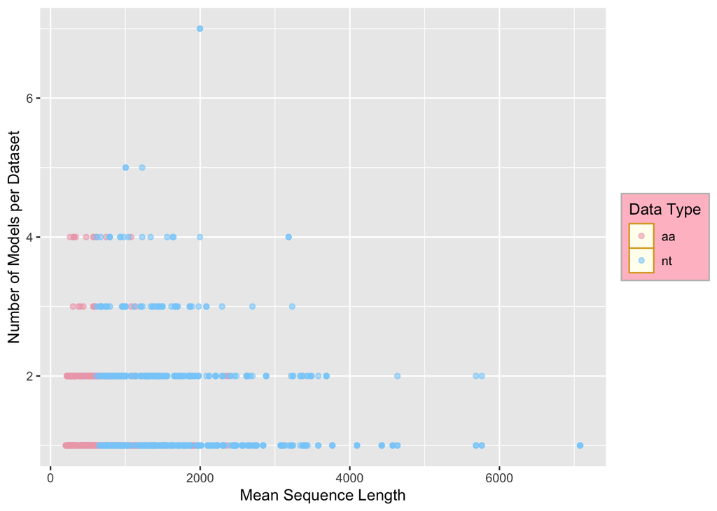

```r
one_csv %>%
  drop_na %>%
  ggplot(aes(x =mean_seq_length, y = number_models)) +
  geom_point(alpha = 0.6, aes(color = data_type)) +
  scale_color_manual("Data Type",labels=c("aa","nt"),values=c('pink2','lightskyblue')) +
  theme(legend.key=element_rect(color="goldenrod", fill = "ivory1"),legend.background = element_rect(fill="pink", color = "grey")) +
  scale_x_continuous(name= "Mean Sequence Length") +
  scale_y_continuous(name="Number of Models per Dataset")
```

This plot can virtually be ignored, it was meant to be a test. I enjoyed picking out the colors though. Time for the real deal (faceting!)

# Plot Two - Starting to Facet!

The following plot will be Number of Models per Dataset per Mean Sequence Length.

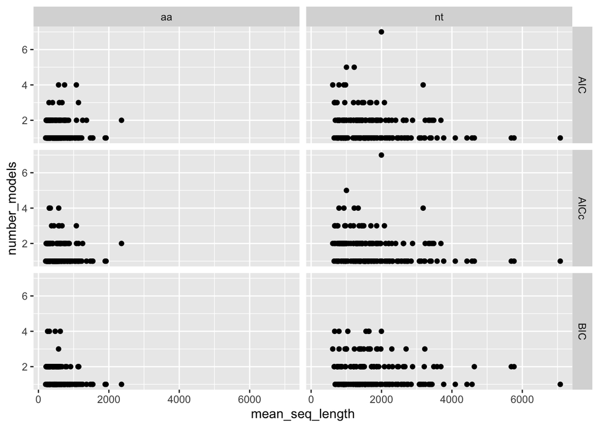

```r
one_csv %>%
  drop_na() %>%
  ggplot(aes(x=mean_seq_length,y=number_models)) +
  geom_point() +
  facet_grid(ic_type ~data_type)
```

Alright, so that plot has all the faceting it needs, but it’s boring! Let’s add colors and change around the axis titles and maybe even the legend! Perhaps I will even give the plot a title ohohhoh.

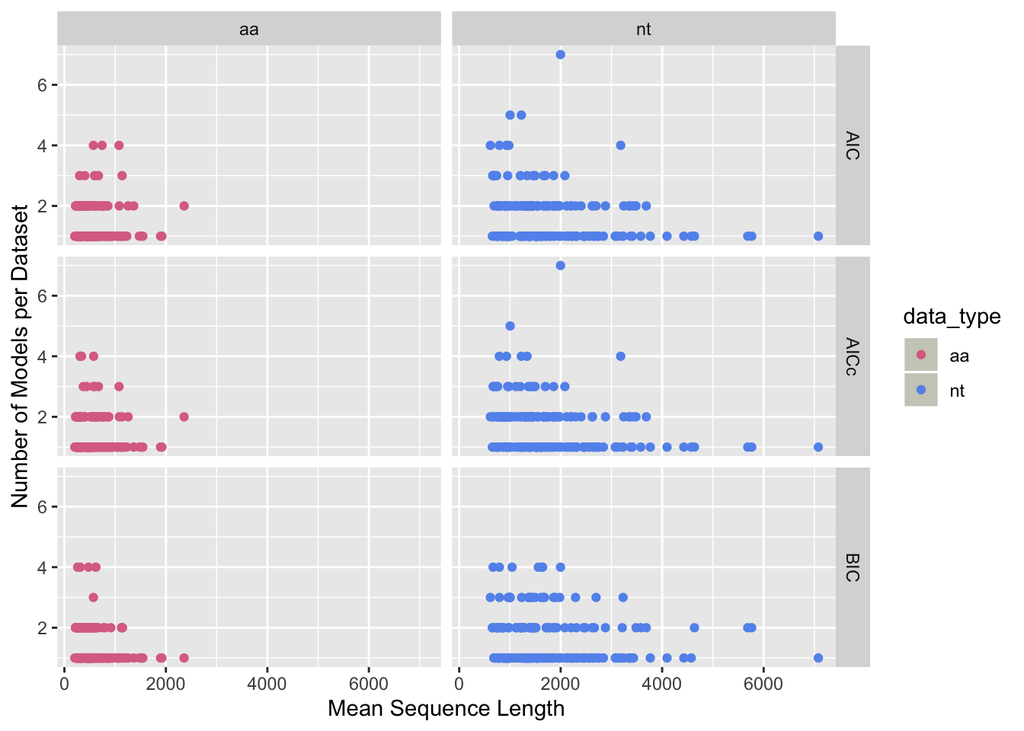

```r
one_csv %>%
  drop_na() %>%
  ggplot(aes(x=mean_seq_length,y=number_models)) +
  geom_point(aes(color=data_type)) +
  facet_grid(ic_type ~data_type) +
  scale_x_continuous(name="Mean Sequence Length") +
  scale_y_continuous(name="Number of Models per Dataset") +
  scale_color_manual(labels=c("aa","nt"),values=c("palevioletred","cornflowerblue")) +
  theme(legend.key=element_rect(fill="ivory3")) +
  scale_fill_discrete(name="Data Type",breaks=c("aa","nt"),labels=c("Amino Acid Data","Nucleotide Data"))
```

Ok I’ve been trying to change the faceting labels, was using `labeller` function, but to no avail. Will be giving up now.

Ok, I tried using the `labeller` on November 7th. It is now November 10th.

Back to plotting!

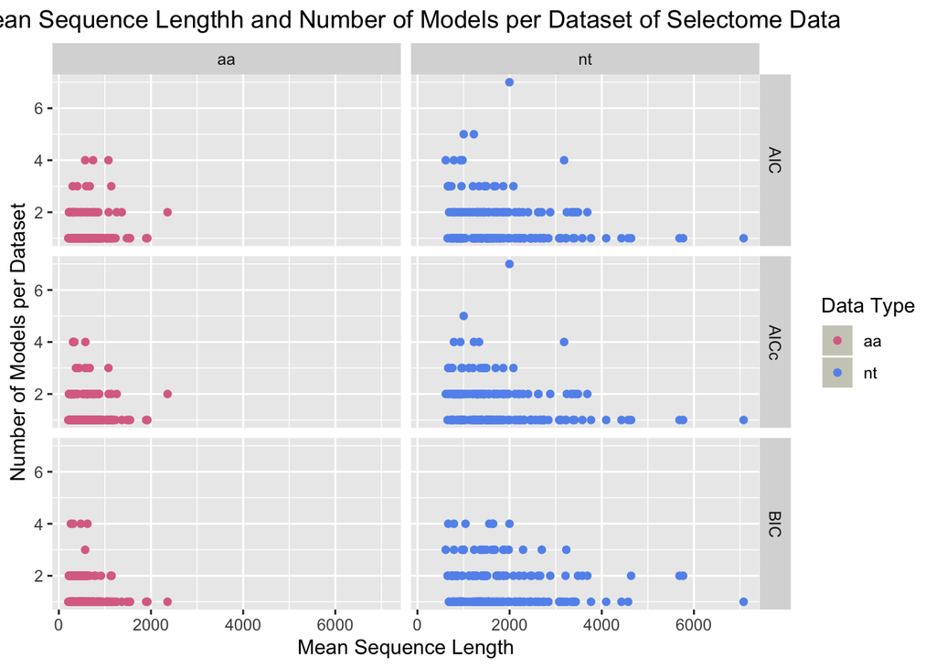

```r
one_csv %>%
  drop_na() %>%
  ggplot(aes(x=mean_seq_length,y=number_models)) +
  geom_point(aes(color=data_type)) +
  facet_grid(ic_type ~data_type) +
  scale_x_continuous(name="Mean Sequence Length") +
  scale_y_continuous(name="Number of Models per Dataset") +
  scale_color_manual("Data Type",labels=c("aa","nt"),values=c("palevioletred","cornflowerblue")) +
  theme(legend.key=element_rect(fill="ivory3"), plot.title=element_text(hjust=0.5)) +
  scale_fill_discrete(labels=c("Amino Acid Data","Nucleotide Data")) +
  ggtitle("Mean Sequence Lengthh and Number of Models per Dataset of Selectome Data")
```

Added a title, and am still trying to change label names. Not sure why they won’t change when I’m using `scale_fill_discrete` and the `label=c()` function.